# 9: Exercise on classification

Rohit Koonireddy

2023-11-19

# An exercise ~guided tour~ on linear classificaiton using logistic regression

## Intro

In this exercise session, we gonna explore together *classification*, as for the tutorial, as close as possible to what we have seen in the lecture. Supervised classification works exactly the same as for regression: our model is the solution of a minimization problem, that has the optimum when classes are optimally separated on the training set. While for a regression problem we were interested at *approximating* a function, here we want our function to be *separating* discrete object classes, or providing us with a probability which tells us how likely is a given data point to belong to one class.

## Data

In this exercise, we gonna classify our beloved *Iris* dataset, and no longer clustering it. We should not have problems with the duplicate entry in our datatable, as we had when checking whether the Euclidean distance is valid (which should have been, otherwise!). We will prevent numerical instabilities explicitly.

### Objectives

The aim of these practicals is to cover one of the most important classification method: logistic regression and its multiclass extension. As for the tutorial, we gonna see two different implementation of the classifier, a binary logitic regression implementation using `glm` a custom multiclass implementation using `Keras` on `TensorFlow`. As for regression, the step between a simple linear model to more complex deep learning classifier is really short!

Here, we want to: - Overview classification using logistic regression models - Hands on `TensorFlow` through the `Keras` API and gain an idea how NNs are built - Explore the solutions in terms of input space decision function - Quickly compute some assessment and check and compare results

## Exercise

### Logistic Regression

So far we have studied gradient descent in the context of linear regression. Such a linear model is given by the following formula: $y = w_1x_1 +...+ w_nx_n + b = \mathbf{w}\mathbf{x}+ b$ in vector notation.

where $y$ is measured on a continuous scale, $x_i$ are the $ i ,,d$ features for a $d$-dimensional dataset and $w_i$ are the weights we are trying to estimate.

Recall from lecture that by applying a sigmoid function to the right-hand side of the above equation, you transition from a linear regression to a logistic regression. Unlike for linear regressions, the outputs or predictions from a logistic regression are not continuous. Logistic regressions can be used to model targets that lie in the range [0,1], such as probabilities. It is most commonly used to model binary targets (e.g., this image does contain a cat (presence) vs. this image does not contain a cat (absence)). Multi-class extensions of the standard logistic regression combine multiple binary classifiers. We gonna first check a binary problem, and then extend to multiclass using `TensorFlow`.

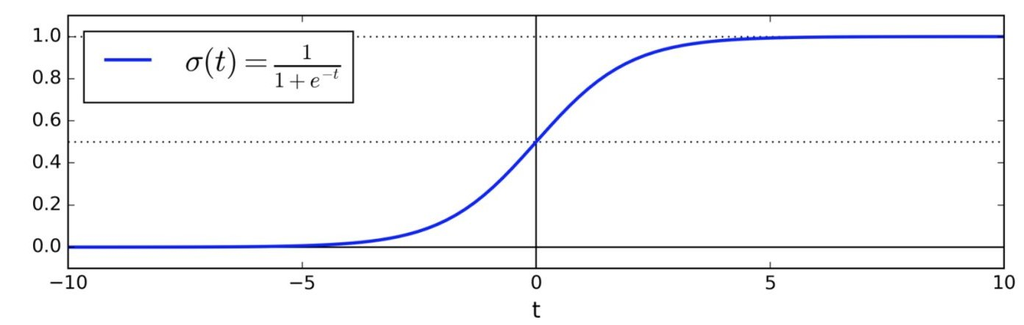

Visualization of a logistic function.

In a nutshell, logistic regression is just a linear model, which is trained to best split two classes. On top of this, there is an activation function, which in this case is just a re-normalisation, which converts the range to a probability. This activation is called `sigmoid` for binary problems, and is seen as a link function in a generalised linear model, which uses a `binomial` distribution. Any values of $t$ below 0 will result in a probability closer to 0 (e.g no cat), while any values of $t$ above 0 will result in a probability closer to 1 (e.g. presence of a cat). You can very easily show that:

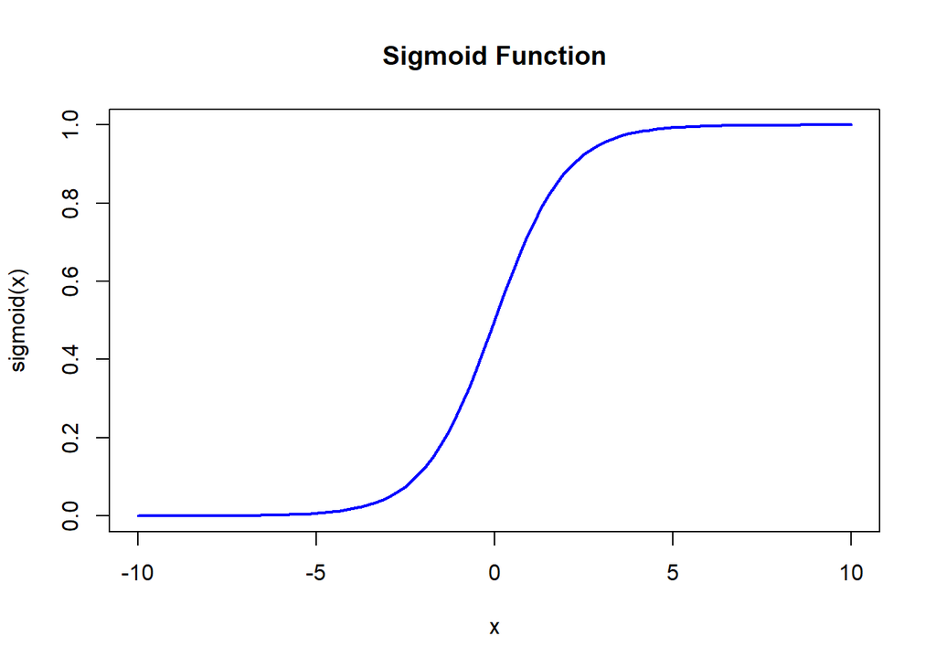

```r
# create a vector ranging from , sort it and pass it through the sigmoid function and plot it to see how it looks like!

# create a vector ranging from -10 to 10
x <- seq(-10, 10, length.out = 100)

# sort the vector
x_sorted <- sort(x)

# define the sigmoid function
sigmoid <- function(x) {
  1 / (1 + exp(-x))
}

# apply the sigmoid function to the sorted vector
y <- sigmoid(x_sorted)

# plot the result
plot(x_sorted, y, type = "l", col = "blue", lwd = 2, main = "Sigmoid Function", xlab = "x", ylab = "sigmoid(x)")
```

This is the sigmoid function, which transforms an unbounded score on the real line, here, x-axis, into a value in $[0,1]$ which can be interepreted as a probability.

The parameters of logistic regression can be estimated using gradient descent, just as we did in the tutorial for linear regression, albeit with a different loss function. More on that below.

In the binary case, and one the model parameters have been estimated, the probability that an example belongs to the positive class os $\hat{p} = \sigma(\mathbf{w}\mathbf{x}+ b)$, and a final (discrete) decision – if needed – can very simply be done by classifying as positives all the point that have been assigned a probability greater than 0.5. Note that this threshold can still be tuned (remember ROC curves and threshold selection).

As the sigmoid is a *monotonic* function, a threshold of 0.5 for binarisation of the prediction scores exactly corresponds to 0 crossing: - $\hat{p}\geq 0.5$ when $\mathbf{w}\mathbf{x}+ b \geq 0$ - $\hat{p}< 0.5$ when $\mathbf{w}\mathbf{x} + b < 0$

The equation $\mathbf{w}\mathbf{x}+ b = 0$ is referred to as the *decision boundary* (the vertical black line in the figure above where t=0 on the x-axis and crossing the dotted of 0.5 on the y-axis).

### Training and Loss Function

The objective of training is to find a set of weights $w_1...w_n$ and a bias $b$, such that the model estimates high probabilities for positive instances $(y = 1)$ and low probabilities for negative instances $(y=0)$. How well the model performs this task can be quantified using the following loss function, shown here for a single training example $\mathbf{x}$:

$$\mathrm{Loss}(\boldsymbol{(w,b)}) =
\begin{cases}
-\log{\hat{p}}, &\quad \mathrm{if} \ y \ = \ 1 \\
-\log({1-\hat{p}}), &\quad \mathrm{if} \ y \ = \ 0
\end{cases}$$

This function makes sense because $-\log(\hat{p})$ grows large when $\hat{p}$ approaches 0, so the loss will be large if the model estimates a probability close to 0 for a positive instance. Similarly, $-\log(1-\hat{p})$ grows large when $\hat{p}$ approaches 1, so the loss will be large if the model estimates a probability close to 1 for a negative instance.

The loss function can be applied to the entire training set by taking the average over all training examples. It can be written in a single expression:
$$\mathrm{Loss}(\boldsymbol{(w,b)}) = -\frac{1}{n}\sum_{i=1}^{n} \left[
y_i\log(\hat{p}_i)+(1-y_i)\log(1-\hat{p}_i)\right]$$

This loss function is called *binary cross-entropy*, as you hopefully remember from the video lectures. Unfortunately, there is no a closed form solution for this loss function, so we have to use heuristics such as the gradient descent algorithm to minimize it.

*IMPORTANT NOTE: READ CAREFULLY!* Do not skip this part or you’ll run into issues later on! In a moment, after you’ve read the following instructions carefully, you should:

- run the code chunk immediately below this text (`set_random_seed(0)`).
- look down in the *Console* it asks if you want to install some packages: (“Would you like to install Miniconda? [Y/n]:”).
- write *n* and press enter. You should see the following code in the console: `Would you like to install Miniconda? [Y/n]: n`.
- if you were too eager and already pressed *Y* (yes) and enter, don’t panic! Just close your environment, re-open it and make sure that next time you go with *n* (no).

```r
library(reticulate)
#use_condaenv('r-reticulate')
library(tensorflow)
library(rjson)
library(tidyverse)
library(patchwork)
library(keras)
library(tensorflow)
library(IRdisplay)

# plot size
options(repr.plot.width = 10, repr.plot.height = 7)
```

### Hands on!

Load and prepare the Iris data as you know! (see the clustering exercise). In addition: - we are going to merge class 1 and 2 to transform that in a binary problem. This allows us to have better control over things. More on the 3 class problem later! - we are only using the *first two features* of Iris, ie, `Sepal.Length` and `Sepal.Width`. - to make things a bit better, we add a small jitter on the data, as already written. This makes sure that data point are not exactly the same.

```r
# Load Iris, split features from labels, change labels
library("datasets")
library("tidyr")
data(iris)

# Merge class 1 and 2 to transform it into a binary problem
iris_binary <- iris
iris_binary$Species <- ifelse(iris_binary$Species %in% c("setosa", "versicolor"), "binary_class", "virginica")

# Use only the first two features (Sepal.Length and Sepal.Width)
X <- iris_binary[, c("Sepal.Length", "Sepal.Width")]
data_types <- sapply(X, class)
# Print the data types
print(data_types)
```

```
## Sepal.Length  Sepal.Width
##    "numeric"    "numeric"
```

```r
# Apply jitter to the specified column
for (col in colnames(X)){
  X[[col]] <- jitter(X[[col]], amount = 0.05, factor = 0.05)

}

# Create a dataframe X_df
X_df <- as.data.frame(X)
X_df$Species <- iris_binary$Species
X <- iris_binary[, c("Sepal.Length", "Sepal.Width")]

# Show summary and check that statistics are not too different after jittering
summary(X)
```

```
##   Sepal.Length    Sepal.Width
##  Min.   :4.300   Min.   :2.000
##  1st Qu.:5.100   1st Qu.:2.800
##  Median :5.800   Median :3.000
##  Mean   :5.843   Mean   :3.057
##  3rd Qu.:6.400   3rd Qu.:3.300
##  Max.   :7.900   Max.   :4.400
```

```r
summary(X_df)
```

```
##   Sepal.Length    Sepal.Width      Species
##  Min.   :4.345   Min.   :2.041   Length:150
##  1st Qu.:5.109   1st Qu.:2.796   Class :character
##  Median :5.802   Median :3.011   Mode  :character
##  Mean   :5.842   Mean   :3.058
##  3rd Qu.:6.387   3rd Qu.:3.312
##  Max.   :7.859   Max.   :4.435
```

Yes, not too different.

Now plot the data. We see that in our binary problem classes are not perfectly separable in the 2D plane `Sepal.Length` and `Sepal.Width` that we created, for academic purposes of course.

```r
str(X_df)
```

```
## 'data.frame':    150 obs. of  3 variables:
##  $ Sepal.Length: num  5.09 4.88 4.73 4.65 5.04 ...
##  $ Sepal.Width : num  3.48 3.03 3.23 3.15 3.64 ...
##  $ Species     : chr  "binary_class" "binary_class" "binary_class" "binary_class" ...
```

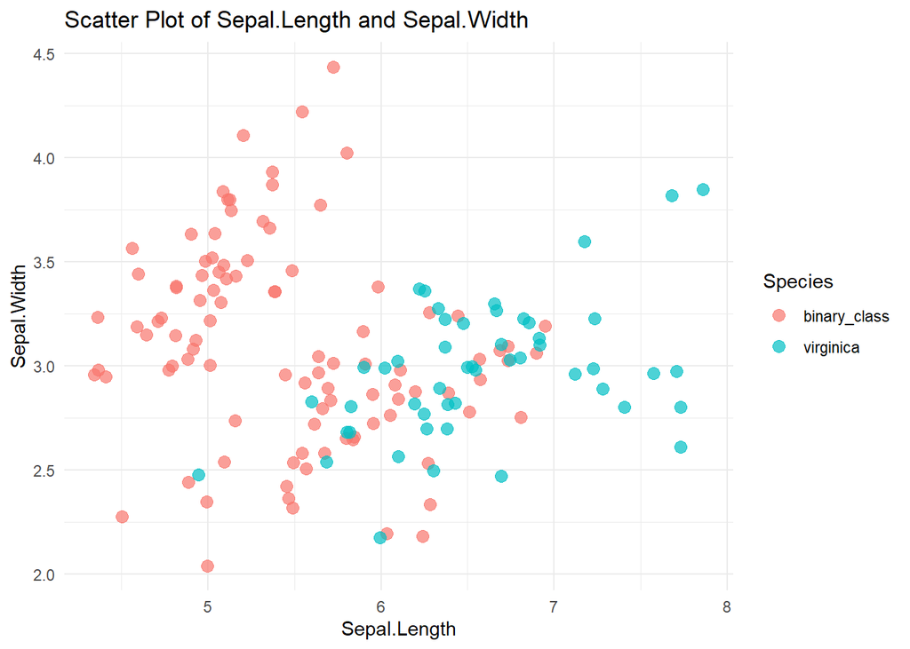

```r
library(ggplot2)

#Plot the data
ggplot(X_df, aes(x = Sepal.Length, y = Sepal.Width, color = Species)) +
  geom_point(size = 3, alpha = 0.7) +
  labs(title = "Scatter Plot of Sepal.Length and Sepal.Width",
       x = "Sepal.Length", y = "Sepal.Width", color = "Species") +
  theme_minimal()
```

Prepare the data for training and testing, by shuffling and using an 60/40 training to test split.

```r
set.seed(556)  # Set a seed for reproducibility

# Sample indices for training (60%) and testing (40%)
ind_tr <- sample(seq_len(nrow(X_df)), size = 0.6 * nrow(X_df))
ind_ts <- setdiff(seq_len(nrow(X_df)), ind_tr)

# Verify that training and testing indices have no element in common
print(any(ind_tr %in% ind_ts))  # Should print FALSE
```

```
## [1] FALSE
```

```r
# Prepare learning dataframes df_tr and df_ts containing features and labels
df_tr <- X_df[ind_tr, ]
df_ts <- X_df[ind_ts, ]
df_tr$y <- ifelse(df_tr$Species == "binary_class", 1, 0)
df_ts$y <- ifelse(df_ts$Species == "binary_class", 1, 0)
```

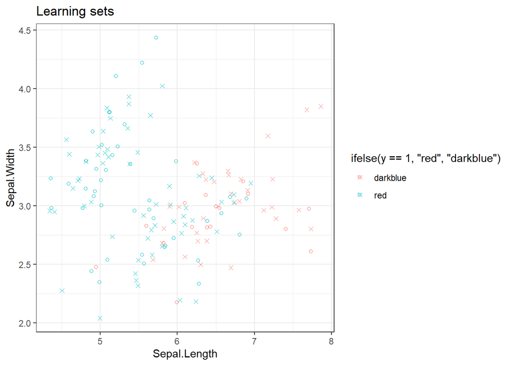

```r
ggplot() +
  geom_point(df_tr, mapping=aes(x=Sepal.Length, y=Sepal.Width, col = ifelse(y == 1, "red", "darkblue")), shape=4) +
  geom_point(df_ts, mapping=aes(x=Sepal.Length, y=Sepal.Width, col = ifelse(y == 1, "red", "darkblue")), shape=1) +
  theme_bw() + labs(title = bquote('Learning sets'))
```

```r
# count labels per learning set
label_counts_tr <- table(df_tr$y)
label_counts_ts <- table(df_ts$y)

# Print the counts
print("Training Set Label Counts:")
```

```
## [1] "Training Set Label Counts:"
```

```r
print(label_counts_tr)
```

```
##
##  0  1
## 33 57
```

```r
print("Testing Set Label Counts:")
```

```
## [1] "Testing Set Label Counts:"
```

```r
print(label_counts_ts)
```

```
##
##  0  1
## 17 43
```

A more appropriate way to split the data would be to use the `r-sample` package and select stratified samples according to the labels. Balancing data classes is crucial for extremely imbalanced problems, but in general, we want training and test distributions to be as similar as possible. Class proportions are hence preserved.

Use the `glm` function to fit a logistic regression model to the training data. For a logistic regression model the appropriate `family = binomial`. We now train a logistic regression using `glm` on the training set, and predict it on both training and test sets.

*Note*: we cannot model 3 classes with one logistic regression, but a common strategy would be to use a “one-versus-all” model, where we train 3 binary models separating in turns class 1 from the rest, class 2 from the rest and class 3 from the rest, where “the rest” are all the other classes merged into one. We then aggregate probabilities and assign a point to the highest one.

I use caret package to do stratified sampling

```r
require(caret)
set.seed(556)

# Create a stratified sample index
stratified_index <- createDataPartition(X_df$Species, p = 0.6, list = FALSE)

# Create training and testing sets based on the index
df_tr <- X_df[stratified_index, ]
df_ts <- X_df[-stratified_index, ]
df_tr$y <- ifelse(df_tr$Species == "binary_class", 1, 0)
df_ts$y <- ifelse(df_ts$Species == "binary_class", 1, 0)

print(table(df_tr$y))
```

```
##
##  0  1
## 30 60
```

```r
print(table(df_ts$y))
```

```
##
##  0  1
## 20 40
```

```r
# add glm here and be sure that labels are 0 or 1, and not 1 and 2
lg_fit <- glm(y ~ Sepal.Length + Sepal.Width - 1, data = df_tr, family = binomial)

summary(lg_fit)
```

```
##
## Call:
## glm(formula = y ~ Sepal.Length + Sepal.Width - 1, family = binomial,
##     data = df_tr)
##
## Deviance Residuals:
##     Min       1Q   Median       3Q      Max
## -1.7387  -1.1286   0.4598   0.9923   1.7066
##
## Coefficients:
##              Estimate Std. Error z value Pr(>|z|)
## Sepal.Length  -0.9081     0.2726  -3.331 0.000866 ***
## Sepal.Width    2.0509     0.5696   3.601 0.000317 ***
## ---
## Signif. codes:  0 '***' 0.001 '**' 0.01 '*' 0.05 '.' 0.1 ' ' 1
##
## (Dispersion parameter for binomial family taken to be 1)
##
##     Null deviance: 124.766  on 90  degrees of freedom
## Residual deviance:  99.726  on 88  degrees of freedom
## AIC: 103.73
##
## Number of Fisher Scoring iterations: 4
```

This means examples with $f(\mathbf{x}) \geq 0$ are predicted to have a label of `1` (i.e., they belong to the ‘positive class’), whereas examples with $f(\mathbf{x}) < 0$ are predicted to have a label of `0` (i.e., they belong to the ‘negative class’).

We can now predict the model on both training and test sets. We can use the argument `type="response"` to the function `predict` to obtain the output of the sigmoid, ie, the probabilities.

```r
predictions_tr <- predict(lg_fit, newdata = df_tr, type = "response")
predictions_ts <- predict(lg_fit, newdata = df_ts, type = "response")
```

We can leave that aside for a second and look at the decision surface. Let’s plot the learned sigmoid function in 2D!

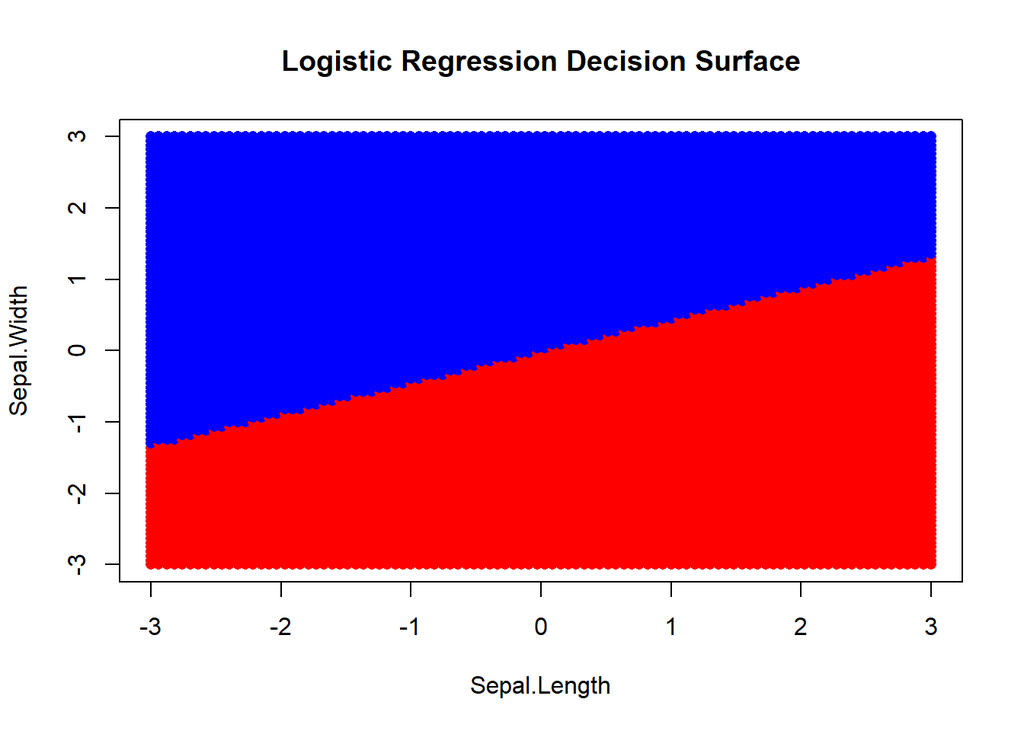

```r
# Create a grid for scatter plot
#create a grid of values ranging from -3 to 3, for each input dimension for IRIS
npoints <- 100
grid_values <- seq(-3, 3, length.out = npoints)
grid <- expand.grid(
  Sepal.Length = grid_values,
  Sepal.Width = grid_values
)

# Predict probabilities on the grid
grid_predictions <- predict(lg_fit, newdata = grid, type = "response")

# Reshape the predictions for scatter plotting
z_grid <- matrix(grid_predictions, nrow = npoints, ncol = npoints)

# Plot the scatter plot
plot(
  x = grid$Sepal.Length,
  y = grid$Sepal.Width,
  col = ifelse(z_grid >= 0.5, "blue", "red"),  # Color points based on predicted probabilities
  pch = 16,
  xlab = "Sepal.Length",
  ylab = "Sepal.Width",
  main = "Logistic Regression Decision Surface"
)

# Add points for the training and testing sets
points(
  x = c(df_tr$Sepal.Length, df_ts$Sepal.Length),
  y = c(df_tr$Sepal.Width, df_ts$Sepal.Width),
  col = c(ifelse(predictions_tr >= 0.5, "green", "white"), ifelse(predictions_ts >= 0.5, "green", "white")),
  pch = 16
)
```

```r
#create a grid of values ranging from -3 to 3, for each input dimension for IRIS
npoints = 100
d1 = kronecker(matrix(1,1,npoints),c(1:npoints))
grid = cbind(matrix(t(d1), nrow = npoints^2, byrow = TRUE), matrix(d1, nrow = npoints^2, byrow = TRUE))
grid = (grid / npoints) * 5 -2
```

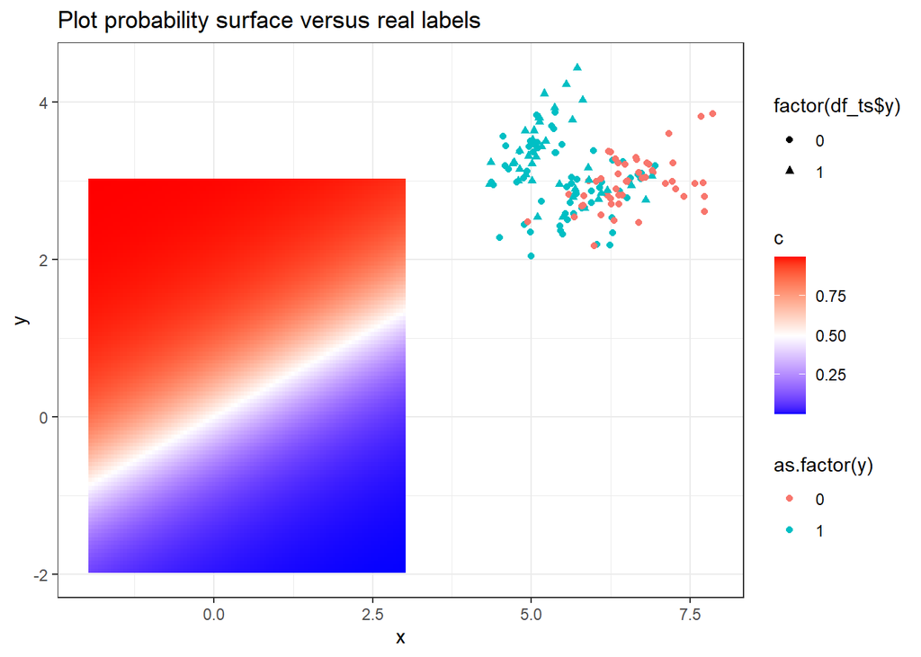

```r
df_grid = data.frame(Sepal.Length = grid[, 1], Sepal.Width = grid[, 2])

# Predict the probability for the grid defined above
pred = predict(lg_fit, newdata = df_grid, type = "response")

# Store it in a df_pred data.frame
df_pred = data.frame(x = df_grid$Sepal.Length, y = df_grid$Sepal.Width, c = pred)

# Create a data frame for predicted labels
df_pred_labels = data.frame(x = df_grid$Sepal.Length, y = df_grid$Sepal.Width, label = ifelse(pred >= 0.5, 1, 0))

library(ggplot2)

# Plot probability surface versus real labels
ggplot() +
  geom_tile(data = df_pred, aes(x = x, y = y, fill = c)) +
  scale_fill_gradient2(low = "blue", high = "red", midpoint = 0.5) +
  geom_point(df_tr, mapping = aes(x = Sepal.Length, y = Sepal.Width, color = as.factor(y))) +
  geom_point(df_ts, mapping = aes(x = Sepal.Length, y = Sepal.Width, color = as.factor(df_ts$y), shape = factor(df_ts$y))) +
  theme_bw() +
  labs(title = bquote('Plot probability surface versus real labels'))
```

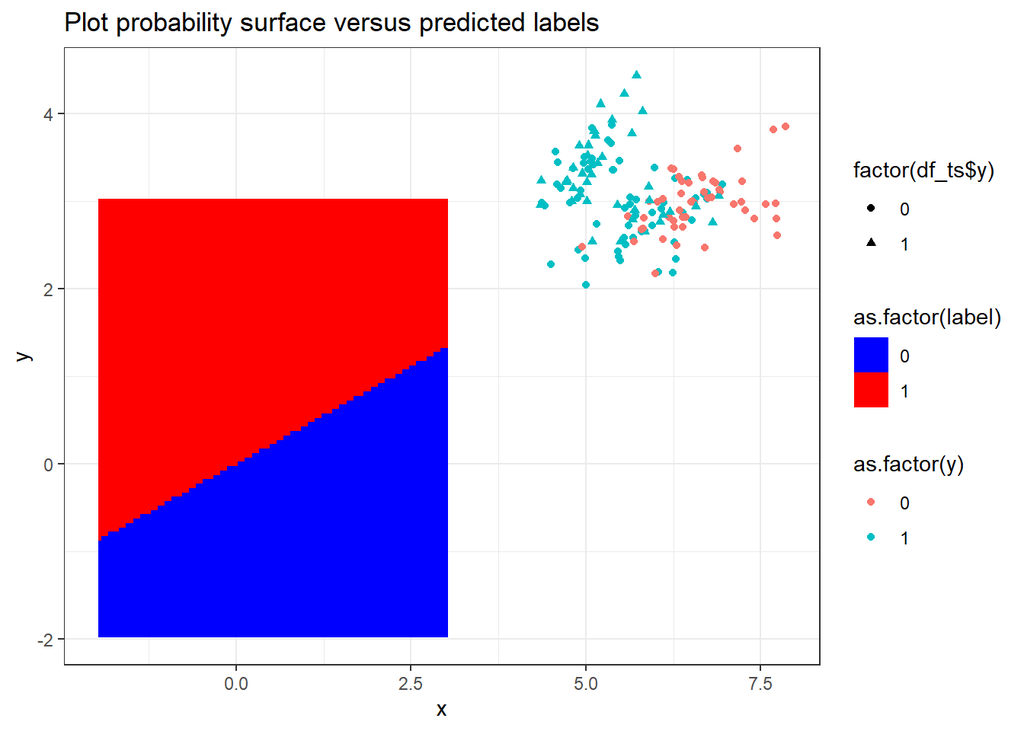

```r
# Plot probability surface versus predicted labels
ggplot() +
  geom_tile(data = df_pred_labels, aes(x = x, y = y, fill = as.factor(label))) +
  scale_fill_manual(values = c("blue", "red")) +
  geom_point(df_tr, mapping = aes(x = Sepal.Length, y = Sepal.Width, color = as.factor(y))) +
  geom_point(df_ts, mapping = aes(x = Sepal.Length, y = Sepal.Width, color = as.factor(df_ts$y), shape = factor(df_ts$y))) +
  theme_bw() +
  labs(title = bquote('Plot probability surface versus predicted labels'))
```

It seems the trained model does a good job at predicting which examples should be associated with which label, in general. Some examples are clearly misclassified, and a linear model in 2D, I am afraid, cannot really do more than that…

Let’s take the predictions from our trained logistic regression, and compute some accuracy scores as seen in the lectures: overall accuracy, precision, recall, and F1.

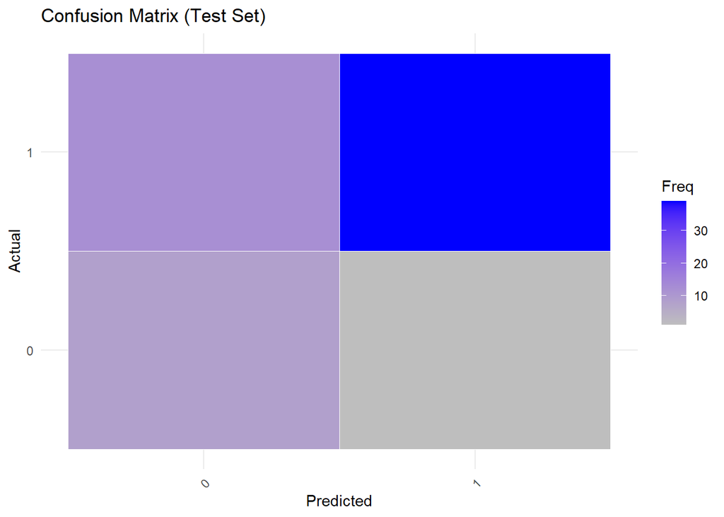

```r
# Function to compute confusion matrix
compute_confusion_matrix <- function(true_labels, predicted_labels) {
  confusion_matrix <- table(true_labels, predicted_labels)
  return(confusion_matrix)
}

# Function to compute accuracy
compute_accuracy <- function(confusion_matrix) {
  accuracy <- sum(diag(confusion_matrix)) / sum(confusion_matrix)
  return(accuracy)
}

# Function to compute precision
compute_precision <- function(confusion_matrix, class_label) {
  precision <- confusion_matrix[class_label, class_label] / sum(confusion_matrix[, class_label])
  return(precision)
}

# Function to compute recall
compute_recall <- function(confusion_matrix, class_label) {
  recall <- confusion_matrix[class_label, class_label] / sum(confusion_matrix[class_label, ])
  return(recall)
}

# Function to compute F1 score
compute_f1_score <- function(precision, recall) {
  f1_score <- 2 * (precision * recall) / (precision + recall)
  return(f1_score)
}

# Test set metrics
confusion_matrix_test <- compute_confusion_matrix(df_ts$y, ifelse(predictions_ts >= 0.5, 1, 0))
accuracy_test <- compute_accuracy(confusion_matrix_test)
precision_test <- compute_precision(confusion_matrix_test, 1)  # Assuming class 1 is the positive class
recall_test <- compute_recall(confusion_matrix_test, 1)
f1_score_test <- compute_f1_score(precision_test, recall_test)


# Function to plot confusion matrix as a heatmap
plot_confusion_matrix <- function(confusion_matrix, title) {
  df_confusion <- as.data.frame(confusion_matrix)
  ggplot(df_confusion, aes(x = true_labels, y = predicted_labels, fill = Freq)) +
    geom_tile(color = "white") +
    theme_minimal() +
    labs(title = title,
         x = "Predicted",
         y = "Actual") +
    scale_fill_gradient(low = "grey", high = "blue") +
    theme(axis.text.x = element_text(angle = 45, vjust = 1, hjust = 1))
}


# Plot confusion matrix for the test set
plot_confusion_matrix(confusion_matrix_test, "Confusion Matrix (Test Set)")
```

```r
cat("Test Set Metrics:\n")
```

```
## Test Set Metrics:
```

```r
cat("Accuracy:", accuracy_test, "\n")
```

```
## Accuracy: 0.7833333
```

```r
cat("Precision:", precision_test, "\n")
```

```
## Precision: 0.8888889
```

```r
cat("Recall:", recall_test, "\n")
```

```
## Recall: 0.4
```

```r
cat("F1 Score:", f1_score_test, "\n\n")
```

```
## F1 Score: 0.5517241
```

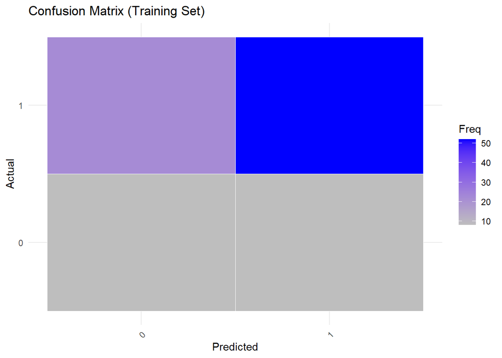

```r
# Training set metrics
confusion_matrix_train <- compute_confusion_matrix(df_tr$y, ifelse(predictions_tr >= 0.5, 1, 0))
accuracy_train <- compute_accuracy(confusion_matrix_train)
precision_train <- compute_precision(confusion_matrix_train, 1)  # Assuming class 1 is the positive class
recall_train <- compute_recall(confusion_matrix_train, 1)
f1_score_train <- compute_f1_score(precision_train, recall_train)


# Plot confusion matrix for the training set
plot_confusion_matrix(confusion_matrix_train, "Confusion Matrix (Training Set)")
```

```r
cat("Training Set Metrics:\n")
```

```
## Training Set Metrics:
```

```r
cat("Accuracy:", accuracy_train, "\n")
```

```
## Accuracy: 0.6666667
```

```r
cat("Precision:", precision_train, "\n")
```

```
## Precision: 0.5
```

```r
cat("Recall:", recall_train, "\n")
```

```
## Recall: 0.2666667
```

```r
cat("F1 Score:", f1_score_train, "\n")
```

```
## F1 Score: 0.3478261
```

We’ve got good scores, isn’it? or not? what can we say by comparing them?

We see that the training set is strongly biased against grouped lables rather than the other one. It is evident that the glm is more biased towards more data but we can also somewhat better results on test set which could be attributed to lesser data.

### Using Keras!

We now are going to translate the regression model of the tutorial into a multi-class classification one! yay! multiclass logistic regression, aka, multinomial logistic regression!

Let’s re-read the Iris dataset, just to be on the save side, but without changing the size of X or the number of classes – we gonna work in it like it is. We still add some jitter, as before, to avoid collinear points.

```r
set.seed(0)
# Load Iris, scale, and jitter
data(iris)

# Scale data
X <- scale(iris[, 1:4])

# Add some small jitter
X_df <- as.data.frame(X + matrix(rnorm(length(X), sd = 0.05), ncol = 4))

# Add species column
X_df$Species <- iris$Species
```

Let’s split data again in 60-40, and create train and test dataframes `df_tr` and `df_ts`.

```r
# We can set a seed for reproducible results.
set.seed(556)

# Create a stratified sample index
stratified_index <- createDataPartition(X_df$Species, p = 0.6, list = FALSE)

# Create training and testing sets based on the index
df_tr <- X_df[stratified_index, ]
df_ts <- X_df[-stratified_index, ]
```

The multiclass cross entropy deals with a multiclass problem directly, but we need to resahpe the labels into a one-hot-encoded vector. We need to create an array of shape N x C, where C is the number of classes. Each column corresponds to one class, and each entry is either a 0 or a 1, which indicates what class is active and which class is not.

`to_cagegorical(class_vector, num_classes=3)` does that for us, but be sure to pass a vector where the first class is 0 and the last 2. Not sure why we are now 0-indexing.

```r
require(keras)

#create onehot for the labels
species <- levels(X_df$Species)
y_integer <- as.integer(X_df$Species)-1
y_one_hot <- to_categorical(y_integer)

y_train_int <- as.integer(df_tr$Species)-1
y_train <- to_categorical(y_train_int)

y_test_int <- as.integer(df_ts$Species)-1
y_test <- to_categorical(y_test_int)

#function to decode species
decode_species <- function(input_species_onehot) {
  return (species[apply(input_species_onehot, 1, function(row) which.max(row))])
}
```

Let’s now define the Keras model, we do not need to first define a function, we can just script the model and the layer concatenation. You are free to test different learning rates, and plot different aspects.

The multiclass cross-entropy is going to be used as loss, which is named `categorical_crossentropy`. As for the regression, we are going to use a `layer_dense(units = N_class, input_shape = D, activation = "softmax")`. Note that N_class is the size of the output of that layer, and the input size is the dimensionality of the data. We are going to use a `softmax` activation, which generalizes the sigmoid.

```r
# HINT: Use right activation and loss functions for logistic regression
save_path_logs <- './'

build_and_train_model <- function(x_train, y_train, learning_rate, num_epochs, batch_size, save_path) {

  x_train <- as.matrix.data.frame(x_train)
  y_train <- as.matrix.data.frame(y_train)
  # Feed-forward (non-recursive) neural nets (MLPs, CNNs, AutoEncoders, etc) and standard models (linear regression, classification) are `sequential` models, as operations are executed along a path with no loops (as opposed to recurrent neural networks for instance)
  model <- keras_model_sequential()

  # Name the model
  model.name <- 'logistic_regression_'

  # Name the log file
  path <- file.path(save_path, 'logs')
  dir.create(path)
  fname <- file.path(path, paste(model.name, 'lr_', toString(learning_rate), '.json', sep = ""))


  model %>% layer_dense(units = 3, input_shape = 4, activation = 'softmax')  # Assuming 3 classes and 4 features

  # Print the model description
  summary(model)

  # Specify the learning rate and learning algorithm for SGD. Here, we use the standard, that we have seen in the lecture online.
  opt <- optimizer_sgd(learning_rate = learning_rate)

  model %>% compile(loss = 'categorical_crossentropy', optimizer = opt, metrics = c("accuracy"))

  if (fname %in% list.files(path, full.names = TRUE)) {
    file.remove(fname)
  }
  json_log <- file(fname)
  json_logging_callback <- callback_lambda(
    on_epoch_end = function(epoch, logs) {
      write(
        toJSON(list(
          epoch = epoch + 1,
          loss = logs[['loss']],
          accuracy = logs[['accuracy']],
          f1_score = logs[['f1_m']],
          W = get_weights(model)[[1]],
          b = get_weights(model)[[2]]
        )),
        file = fname, append = TRUE
      )
    },
    on_train_end = function(logs) {
      close(json_log)
    }
  )

  # Fit the model y = wx + b
  history <- model %>% fit(x_train, y_train,
                           epochs = num_epochs,
                           batch_size = batch_size,
                           callbacks = json_logging_callback
  )

  # Extract W and b
  W <- get_weights(model)[[1]]
  b <- get_weights(model)[[2]]

  return(list(model = model, history = history, W = W, b = b))
}
```

```r
X_train <- df_tr[, !(names(df_tr) %in% c("Species"))]
X_test <- df_ts[, !(names(df_ts) %in% c("Species"))]

set_random_seed(333)

#set parameters
learning_rate <- 0.1
num_epochs <- 60
batch_size <- 64
save_path <- save_path_logs


# Build and train a model
# Note that if a function gives us multiple outputs at once, we can save them at once in individual variables as such:
c(model, history, w_tf, b_tf) %<-%  build_and_train_model(X_train, y_train, learning_rate, num_epochs, batch_size, save_path)
```

```
## Model: "sequential"
## ________________________________________________________________________________
##  Layer (type)                       Output Shape                    Param #
## ================================================================================
##  dense (Dense)                      (None, 3)                       15
## ================================================================================
## Total params: 15 (60.00 Byte)
## Trainable params: 15 (60.00 Byte)
## Non-trainable params: 0 (0.00 Byte)
## ________________________________________________________________________________
## 2/2 - 0s - loss: 1.7239 - accuracy: 0.1333 - 351ms/epoch - 176ms/step
## 2/2 - 0s - loss: 1.4219 - accuracy: 0.2000 - 31ms/epoch - 16ms/step
## 2/2 - 0s - loss: 1.1951 - accuracy: 0.2667 - 17ms/epoch - 8ms/step
## 2/2 - 0s - loss: 1.0269 - accuracy: 0.4000 - 9ms/epoch - 4ms/step
## 2/2 - 0s - loss: 0.8954 - accuracy: 0.4778 - 9ms/epoch - 5ms/step
## 2/2 - 0s - loss: 0.7997 - accuracy: 0.5667 - 108ms/epoch - 54ms/step
## 2/2 - 0s - loss: 0.7261 - accuracy: 0.6222 - 18ms/epoch - 9ms/step
## 2/2 - 0s - loss: 0.6710 - accuracy: 0.6444 - 20ms/epoch - 10ms/step
## 2/2 - 0s - loss: 0.6286 - accuracy: 0.7111 - 11ms/epoch - 6ms/step
## 2/2 - 0s - loss: 0.5919 - accuracy: 0.7556 - 10ms/epoch - 5ms/step
## 2/2 - 0s - loss: 0.5636 - accuracy: 0.7556 - 9ms/epoch - 4ms/step
## 2/2 - 0s - loss: 0.5408 - accuracy: 0.7556 - 12ms/epoch - 6ms/step
## 2/2 - 0s - loss: 0.5207 - accuracy: 0.7889 - 9ms/epoch - 5ms/step
## 2/2 - 0s - loss: 0.5035 - accuracy: 0.8000 - 8ms/epoch - 4ms/step
## 2/2 - 0s - loss: 0.4885 - accuracy: 0.8111 - 9ms/epoch - 4ms/step
## 2/2 - 0s - loss: 0.4757 - accuracy: 0.8111 - 9ms/epoch - 5ms/step
## 2/2 - 0s - loss: 0.4646 - accuracy: 0.8111 - 9ms/epoch - 4ms/step
## 2/2 - 0s - loss: 0.4544 - accuracy: 0.8222 - 9ms/epoch - 4ms/step
## 2/2 - 0s - loss: 0.4446 - accuracy: 0.8222 - 9ms/epoch - 4ms/step
## 2/2 - 0s - loss: 0.4356 - accuracy: 0.8444 - 9ms/epoch - 4ms/step
## 2/2 - 0s - loss: 0.4276 - accuracy: 0.8444 - 8ms/epoch - 4ms/step
## 2/2 - 0s - loss: 0.4203 - accuracy: 0.8444 - 8ms/epoch - 4ms/step
## 2/2 - 0s - loss: 0.4132 - accuracy: 0.8667 - 8ms/epoch - 4ms/step
## 2/2 - 0s - loss: 0.4070 - accuracy: 0.8667 - 12ms/epoch - 6ms/step
## 2/2 - 0s - loss: 0.4008 - accuracy: 0.8889 - 9ms/epoch - 5ms/step
## 2/2 - 0s - loss: 0.3953 - accuracy: 0.8889 - 8ms/epoch - 4ms/step
## 2/2 - 0s - loss: 0.3899 - accuracy: 0.9000 - 9ms/epoch - 4ms/step
## 2/2 - 0s - loss: 0.3850 - accuracy: 0.9000 - 10ms/epoch - 5ms/step
## 2/2 - 0s - loss: 0.3806 - accuracy: 0.9000 - 8ms/epoch - 4ms/step
## 2/2 - 0s - loss: 0.3762 - accuracy: 0.9000 - 9ms/epoch - 4ms/step
```

[output cut: 15 more lines]

```
## 2/2 - 0s - loss: 0.3278 - accuracy: 0.9000 - 8ms/epoch - 4ms/step
## 2/2 - 0s - loss: 0.3257 - accuracy: 0.9000 - 9ms/epoch - 4ms/step
## 2/2 - 0s - loss: 0.3236 - accuracy: 0.9000 - 9ms/epoch - 5ms/step
## 2/2 - 0s - loss: 0.3215 - accuracy: 0.9111 - 9ms/epoch - 4ms/step
## 2/2 - 0s - loss: 0.3194 - accuracy: 0.9111 - 9ms/epoch - 4ms/step
## 2/2 - 0s - loss: 0.3175 - accuracy: 0.9111 - 9ms/epoch - 5ms/step
## 2/2 - 0s - loss: 0.3155 - accuracy: 0.9111 - 9ms/epoch - 5ms/step
## 2/2 - 0s - loss: 0.3137 - accuracy: 0.9111 - 9ms/epoch - 5ms/step
## 2/2 - 0s - loss: 0.3115 - accuracy: 0.9111 - 8ms/epoch - 4ms/step
## 2/2 - 0s - loss: 0.3096 - accuracy: 0.9222 - 9ms/epoch - 5ms/step
## 2/2 - 0s - loss: 0.3075 - accuracy: 0.9222 - 9ms/epoch - 4ms/step
## 2/2 - 0s - loss: 0.3057 - accuracy: 0.9222 - 9ms/epoch - 4ms/step
## 2/2 - 0s - loss: 0.3040 - accuracy: 0.9222 - 9ms/epoch - 4ms/step
## 2/2 - 0s - loss: 0.3023 - accuracy: 0.9222 - 8ms/epoch - 4ms/step
## 2/2 - 0s - loss: 0.3007 - accuracy: 0.9222 - 8ms/epoch - 4ms/step
```

```r
cat('\nFinal solution: w =', w_tf, ' b = ', b_tf, "\n")
```

```
##
## Final solution: w = -0.4918841 0.9835065 -1.11669 -1.376344 0.1164872 -0.7676705 -0.07830752 -0.6190764 -0.06969932 -0.1839884 1.122225 0.5857914  b =  -0.186455 0.5449519 -0.3584968
```

We can now get predictions, and get the probabilities. We then store the index of the class with higher probability in a vector, which makes our final prediction.

```r
# Take probabilities p_ts and p_tr for test and training set, respectively
p_ts <- predict(model, as.matrix.data.frame(X_test))
```

```
## 2/2 - 0s - 65ms/epoch - 32ms/step
```

```r
p_tr <- predict(model, as.matrix.data.frame(X_train))
```

```
## 3/3 - 0s - 21ms/epoch - 7ms/step
```

```r
# get predicted labels from maximal probability
pred_ts <- max.col(p_ts)
pred_tr <- max.col(p_tr)
```

We can pairplot the predicted classes now, and see how those are distributed across training and test.

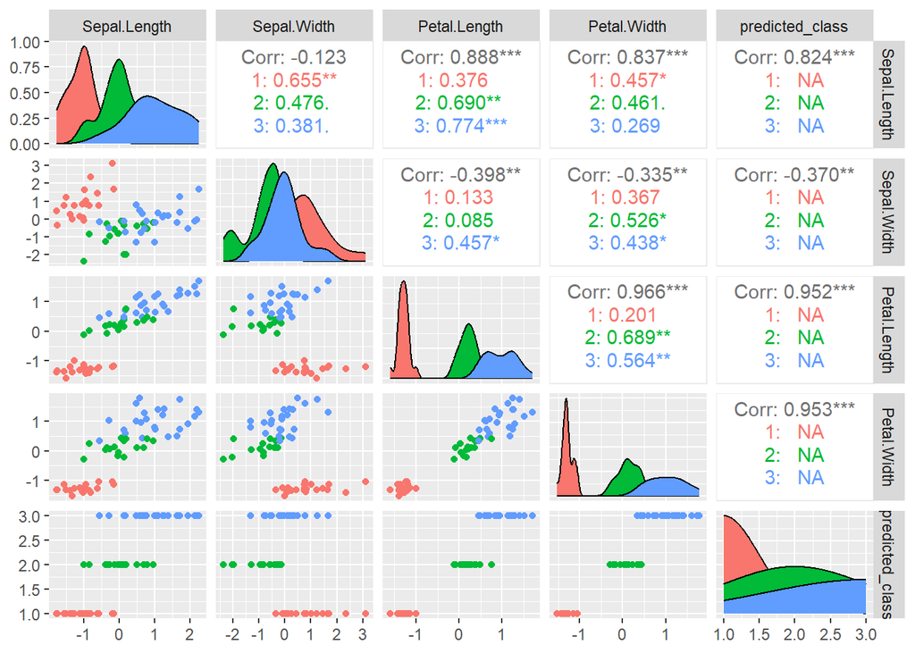

```r
df_ts_pred <- cbind(X_test, predicted_class = pred_ts)
df_tr_pred <- cbind(X_train, predicted_class = pred_tr)

# Load the GGally library
library(GGally)

# Pairplot for test set
ggpairs(df_ts_pred, aes(color = as.factor(predicted_class)))
```

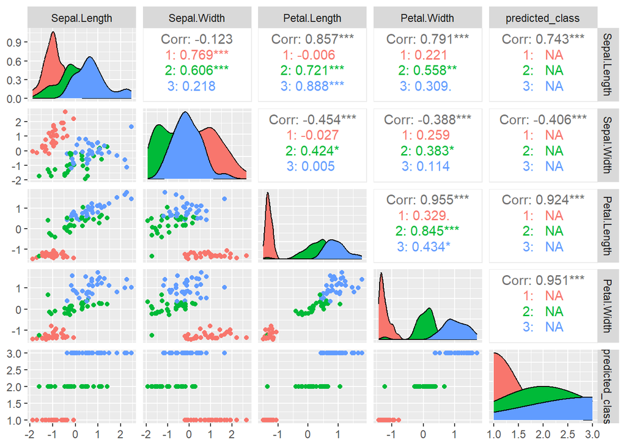

```r
# Pairplot for training set
ggpairs(df_tr_pred, aes(color = as.factor(predicted_class)))
```

We can finally run an accuracy assessment as we did before, and plot the confusion matrix using the snippet given here, where `t_ts` is the cross-tabulation between predictions and ground truth

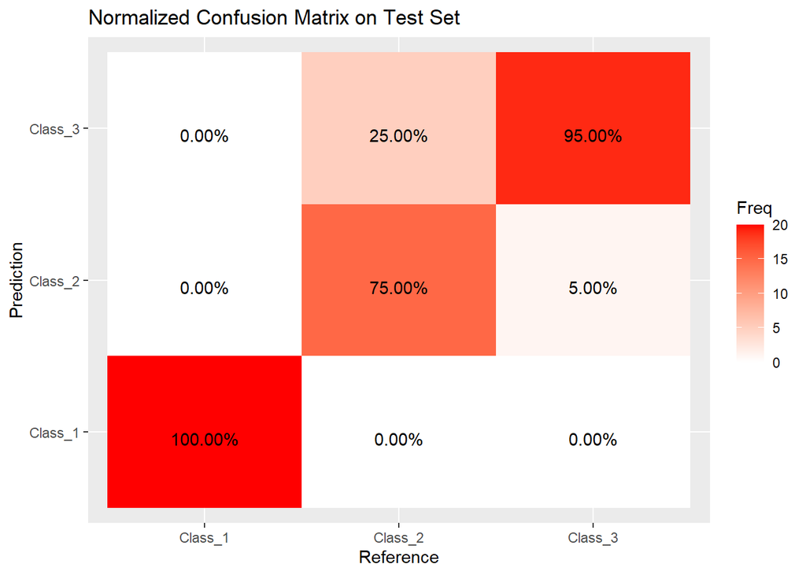

```r
t_ts <- table(decode_species(y_test), decode_species(p_ts))
t_tr <- table(decode_species(y_train), decode_species(p_tr))

df_t_ts = data.frame(t_ts)
fr_r_ts = t_ts / rowSums(t_ts)

df_t_ts$Freq <- as.vector(t_ts)

# Plot normalized confusion matrix
ggplot(df_t_ts, aes(x = Var1, y = Var2, fill = Freq)) +
  geom_tile() +
  geom_text(aes(label = sprintf("%.2f%%", 100 * fr_r_ts)), vjust = 1) +  # Display percentages
  scale_fill_gradient(low = "white", high = "red") +
  labs(x = "Reference", y = "Prediction") +
  scale_x_discrete(labels = c("Class_1", "Class_2", "Class_3")) +
  scale_y_discrete(labels = c("Class_1", "Class_2", "Class_3")) +
  labs(title = bquote("Normalized Confusion Matrix on Test Set"))
```

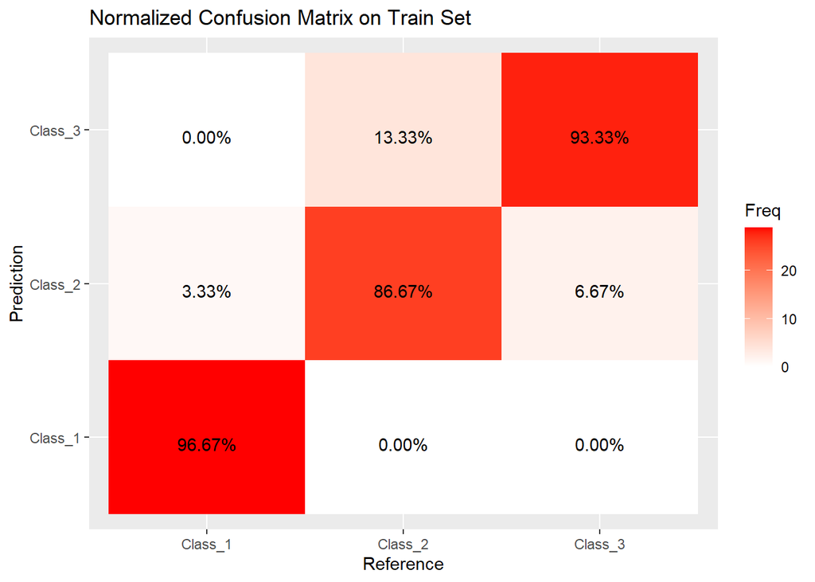

```r
# run accuracy assessment
# compute some metrics for the training set

# Nice plot for training CM
df_t_tr = data.frame(t_tr) # t_tr is the cross-tabulation of the training set
fr_r_tr = t_tr / rowSums(t_tr)
df_t_tr$Freq <- as.vector(t_tr)

ggplot(df_t_tr, aes(x = Var1, y = Var2, fill = Freq)) +
  geom_tile() +
  geom_text(aes(label = sprintf("%.2f%%", 100 * fr_r_tr)), vjust = 1) +  # Display percentages
  scale_fill_gradient(low = "white", high = "red") +
  labs(x = "Reference", y = "Prediction") +
  scale_x_discrete(labels = c("Class_1", "Class_2", "Class_3")) +
  scale_y_discrete(labels = c("Class_1", "Class_2", "Class_3")) +
  labs(title = bquote("Normalized Confusion Matrix on Train Set"))
```

```r
# run accuracy assessment
# Function to compute metrics
compute_metrics <- function(y_true, y_pred) {
  confusion_matrix <- table(y_true, y_pred)

  # Compute accuracy
  accuracy <- sum(diag(confusion_matrix)) / sum(confusion_matrix)

  # Compute precision, recall, and F1 Score for each class
  precision <- diag(confusion_matrix) / rowSums(confusion_matrix)
  recall <- diag(confusion_matrix) / colSums(confusion_matrix)
  f1_score <- 2 * precision * recall / (precision + recall)

  # Compute macro-average and micro-average F1 Score
  macro_avg_f1 <- mean(f1_score, na.rm = TRUE)
  micro_avg_f1 <- sum(diag(confusion_matrix)) / sum(confusion_matrix)

  metrics <- list(
    Accuracy = accuracy,
    Precision = precision,
    F1_Score = f1_score,
    Macro_Avg_F1 = macro_avg_f1,
    Micro_Avg_F1 = micro_avg_f1
  )

  return(metrics)
}

# Compute metrics for test set
metrics_test <- compute_metrics(decode_species(y_test),decode_species(p_ts))

# Compute metrics for training set
metrics_train <- compute_metrics(decode_species(y_train),decode_species(p_tr))

# Print the metrics
print("Metrics for Test Set:")
```

```
## [1] "Metrics for Test Set:"
```

```r
print(metrics_test)
```

```
## $Accuracy
## [1] 0.9
##
## $Precision
##     setosa versicolor  virginica
##       1.00       0.75       0.95
##
## $F1_Score
##     setosa versicolor  virginica
##  1.0000000  0.8333333  0.8636364
##
## $Macro_Avg_F1
## [1] 0.8989899
##
## $Micro_Avg_F1
## [1] 0.9
```

```r
print("Metrics for Training Set:")
```

```
## [1] "Metrics for Training Set:"
```

```r
print(metrics_train)
```

```
## $Accuracy
## [1] 0.9222222
##
## $Precision
##     setosa versicolor  virginica
##  0.9666667  0.8666667  0.9333333
##
## $F1_Score
##     setosa versicolor  virginica
##  0.9830508  0.8813559  0.9032258
##
## $Macro_Avg_F1
## [1] 0.9225442
##
## $Micro_Avg_F1
## [1] 0.9222222
```

What can we say about this evaluation and these numbers? Can we compare that to the binary problem above?

```r
# get_weights from model
weights <- get_weights(model)

# Assuming w_tf and b_tf are the weights and biases for the first layer
w_tf <- weights[[1]]
b_tf <- weights[[2]]

# Display weights and biases
cat('\nModel Attributes: \nweights =', w_tf, ' \nbiases = ', b_tf, "\n")
```

```
##
## Model Attributes:
## weights = -0.4918841 0.9835065 -1.11669 -1.376344 0.1164872 -0.7676705 -0.07830752 -0.6190764 -0.06969932 -0.1839884 1.122225 0.5857914
## biases =  -0.186455 0.5449519 -0.3584968
```